# Short Lab 4

Peiran Chen

As usual, all code below should follow the style guidelines from the lecture slides.

1. **Use the code below to read in data from a survey of 55 Duke University students about their study habits and grades. You can read more about this data at https://www.openintro.org/data/index.php?data=gpa.**

```r
# import dataset
grades_data <- read.csv("https://www.openintro.org/data/csv/gpa.csv")
```

2. **Create a scatter plot with GPA on the y-axis and and hours studied per week on the x-axis. What do you observe?**

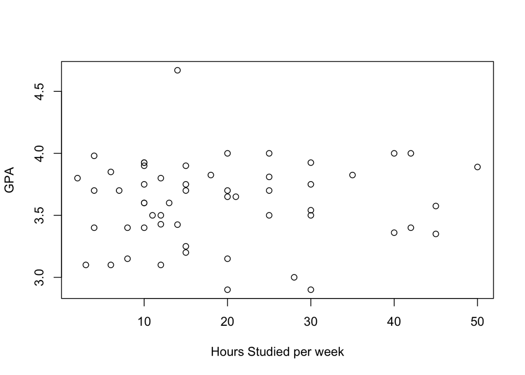

```r
# Plot a scatter plot with GPA as y-axis and hours studied per week on x-axis.
plot(grades_data$studyweek, grades_data$gpa,
     xlab = "Hours Studied per week", ylab = "GPA")
```

I see the points to be scattered around a lot. And there seems to not have a correlation between GPA and hours studied

3. **Use the `lm` function to regress `gpa` upon `studyweek`. What are the estimated coefficients? What are their interpretations?**

```r
# Performing regression to regress gpa upon studyweek
lm_studyweek <- lm(grades_data$gpa ~ grades_data$studyweek)
```

Estimated coefficients are 3.5784902, 0.0011273. And it means that for one more hour studied per week, student’s GPA is going up by 0.001127. And if a student does not study at all, their GPA will be 3.57

4. **Use the `lm` function to regress `gpa` upon `sleepnight` and `studyweek`. What are the estimated coefficients? What are their interpretations?**

```r
# Performing regression to regress gpa upon studyweek and sleepnight
lm_sleepnight_studyweek <- lm(grades_data$gpa ~ grades_data$sleepnight + grades_data$studyweek)
lm_sleepnight_studyweek
```

```
##
## Call:
## lm(formula = grades_data$gpa ~ grades_data$sleepnight + grades_data$studyweek)
##
## Coefficients:
##            (Intercept)  grades_data$sleepnight   grades_data$studyweek
##               3.410584                0.022872                0.001459
```

5. We can write the model used in question 4 as
   $$\mathbf{Y}=\mathbf{X}\boldsymbol\beta+\boldsymbol\epsilon$$
   . What is $\mathbf{Y}$ here? What is $\mathbf{X}$ here. Create the matrix $X$ in your .Rmd file and print out the first six rows.

$\mathbf{Y}$ here means GPA

```r
# Generating X,Y for the given dataset and formula in question 4.
formula <- grades_data$gpa ~ grades_data$sleepnight + grades_data$studyweek
X <- model.matrix(formula, grades_data)
frame <- model.frame(formula, grades_data)
Y <- model.response(frame)
#Print out the first 6 rows of X
head(X, 6)
```

```
##   (Intercept) grades_data$sleepnight grades_data$studyweek
## 1           1                      6                    50
## 2           1                      6                    15
## 3           1                      7                    15
## 4           1                      6                    10
## 5           1                      7                    25
## 6           1                      7                    20
```